# Prosjektoppgave SOK-1005

Kandidatnummer 51

2022-06-06

```r
library(tidyverse)
library(lubridate)
library(dplyr)
library(readr)
library(ggplot2)
library(stringr)
library(zoo)
```

# Oppgave 1

```r
# importerer de 6 datasettene
AwichSA <- read_csv("AppWichStoreAttributes.csv")
county_crime <- read_csv("county_crime.csv")
county_demographic <- read_csv("county_demographic.csv")
county_employment <- read_csv("county_employment.csv")
weekly_sales <- read_csv("weekly_sales_10stores.csv")
weekly_weather <- read_csv("weekly_weather.csv")

# slår sammen datasettene som viser statistikk for hver 'county'
county_stats <- list(county_crime, county_demographic, county_employment) %>%
  reduce(full_join, by = "County_Name")

# slår sammen datasettene som viser statistikk for hver butikk
store_stats <- merge(x = AwichSA, y = weekly_sales, by.x = "Store_Num",
                      by.y = "Store_num")

# legger til kolonne for uke i 'store_stats'
## starter med å lage ny kolonne for dato med type: "Date" og ikke "Chr"
store_stats$Date <- as.Date(store_stats$Date, format = "%m/%d/%Y")

store_stats <- store_stats %>%
  mutate(Week = week(Date))

## endrer kolonnenavn i 'weekly weather'
weekly_weather <- weekly_weather %>%
  rename(Week = Weather_Week,
         Store_Weather_Station = Weather_Station)


# legger til datasettet for værstatistikken i datasettet for butikkstatistikken
stats <- full_join(store_stats, weekly_weather, by = c("Week", "Store_Weather_Station"))

# legger til datasettet for countystats
county_stats <- county_stats %>%
  mutate(Store_County = County_Name)

stats <- full_join(stats, county_stats, by = "Store_County")
```

# Oppgave 2

Her skal jeg velge et utsalgssted for å lage en kortsiktig individuell salgsrapport. Jeg ønsker å se på om været har noe å si når det kommer til hva som selger, og hvor mye som selger. Å ha oversikt over hva som selger avhengig av vær (og dermed årstid) kan føre til mer profitabel drift ved at man kan forberede seg og kjøpe inn mer av visse råvarer og så videre. Samtidig kan man også unngå å overbemanne ved dårlige tider, og å underbemanne i perioder med varme og fint vær (ferier). Videre skal jeg også se på hvilke sandwicher som utgjør størst andel av salget på en ukentlig basis, og om disse er de samme som har høyest profitt-margin.

Jeg ønsker å få oversikt over bedriftene før jeg begår valget om hvilket utsalgssted jeg skal se nærmere på. Derfor lager jeg et kakediagram for å få oversikt over fylkenes profitt og arbeidsstyrke - som jeg ser på som potensielle kunder.

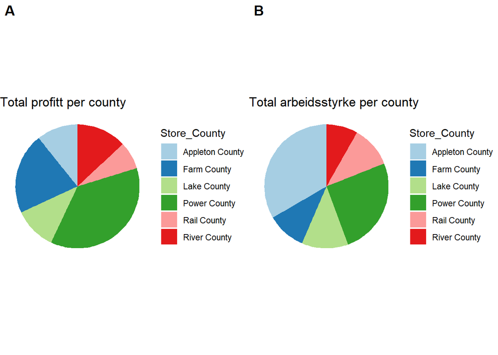

```r
q <- stats %>%
  group_by(Store_County) %>%
  mutate(Total_Profit = sum(Profit)) %>%
  select(Store_County, Total_Profit, County_Labor_Force,
         County_Unemployment_Rate) %>%
  distinct(Store_County, .keep_all = TRUE)

library(cowplot)

plot_grid(ggplot(q, aes(x="", y=Total_Profit, fill=Store_County)) +
            labs(title = "Total profitt per county") +
            geom_bar(stat="identity", width=1) +
            coord_polar("y", start=0) +theme(legend.position="none") +
            theme_void() +
            scale_fill_brewer(palette="Paired"),
          ggplot(q, aes(x="", y=County_Labor_Force, fill=Store_County)) +
            labs(title = "Total arbeidsstyrke per county") +
            geom_bar(stat="identity", width=1) +
            coord_polar("y", start=0) +theme(legend.position="none") +
            theme_void() +
            scale_fill_brewer(palette="Paired"),
          ncol = 2,
          labels = "AUTO")
```

```r
q %>%
  arrange(-County_Unemployment_Rate) %>%
  head()
```

| Store_County | Total_Profit | County_Labor_Force | County_Unemployment_Rate |
| --- | --- | --- | --- |
| Appleton County | 362474.4 | 121082 | 10.6 |
| Rail County | 241926.4 | 39167 | 9.7 |
| Lake County | 374081.6 | 43914 | 9.5 |
| Power County | 1238373.4 | 92041 | 9.3 |
| Farm County | 711731.2 | 36674 | 9.1 |
| River County | 439350.9 | 29564 | 7.5 |

Fylket med størst forskjell mellom arbeidsstyrke og inntekt viser seg å være Appleton, som kun har en butikk. Dette synes jeg er interessant, så derfor velger jeg å se nærmere på dette utsalget. Det viser seg også at Appleton er det fylket med størst arbeidsledighet.

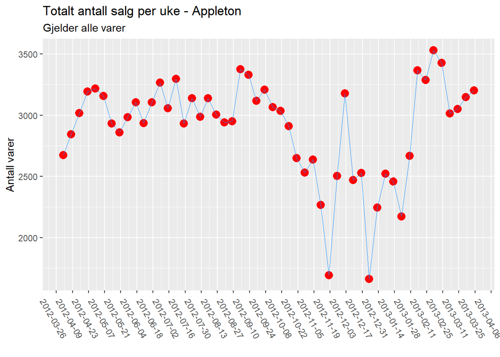

```r
Oppgave2 <- stats %>%
  select(Store_County, Store_Num, Description, Sold, Sales, Price, Profit, Margin,
         County_Labor_Force, County_Unemployment_Rate, Date, Week, Year,
         Weather_Bad_Weather_days) %>%
  filter(Store_County == 'Appleton County') %>%
  group_by(Week) %>%
  mutate(YearWeek = paste(Year, Week, sep = " / "),
         Total_Sales_Week = sum(Sold),
         Total_Profit_Week = sum(Profit))

Oppgave2 <- Oppgave2 %>%
  mutate(Total_Profit_Week = sum(Profit))

Oppgave2 %>%
  ggplot(aes(x=Date, y=Total_Sales_Week)) +
  geom_point(color = "red", size = 3.5) +
  geom_line(aes(x=Date, y=Total_Sales_Week),color = "dodgerblue",size = 0.1) +
  labs(title = "Totalt antall salg per uke - Appleton",
       subtitle = "Gjelder alle varer",
       x = "",
       y = "Antall varer") +
  scale_x_date(date_breaks = "2 weeks") +
  theme(axis.text.x = element_text(angle = -60))
```

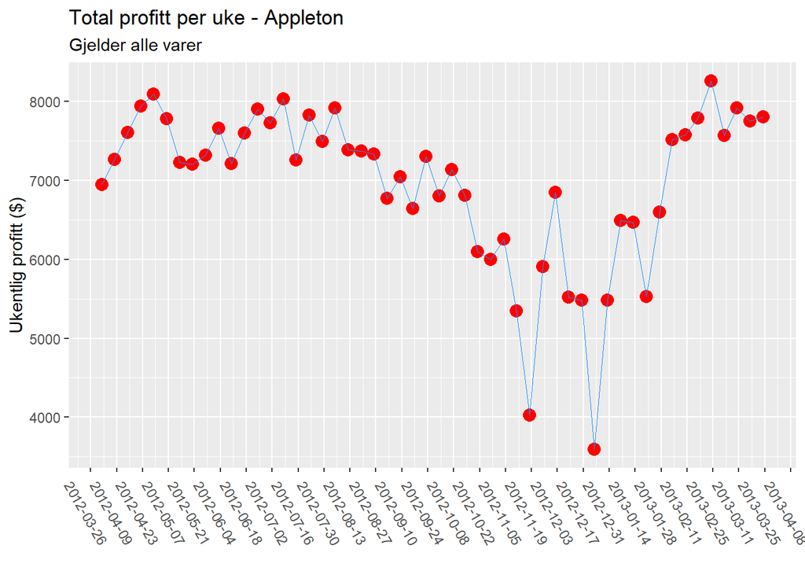

```r
Oppgave2 %>%
  ggplot(aes(x=Date, y=Total_Profit_Week)) +
  geom_point(color = "red", size = 3.5) +
  geom_line(aes(x=Date, y=Total_Profit_Week),color = "dodgerblue",size = 0.1) +
  labs(title = "Total profitt per uke - Appleton",
       subtitle = "Gjelder alle varer",
       x = "",
       y = "Ukentlig profitt ($)") +
  scale_x_date(date_breaks = "2 weeks") +
  theme(axis.text.x = element_text(angle = -60))
```

Disse figurene viser bedriftens ukentlige salg og profitt i Appleton. Her er det spesielt to uker som skiller seg ut negativt. Imidlertid kan man se på datoene at dette er ved ulike høytider, enten det er thanksgiving eller jul. Mitt ønske er derimot å se på en “normal” uke. Derfor velger jeg vilkårlig en uke i “sommer-halvåret”. Jeg velger uke 25 i 2012, som er i juni. I tillegg har bedriften såpass mange varer at jeg velger å begrense ned datasettet. Ettersom dette skal være en amerikansk hurtigmat-kjede som spesifiserer seg på sandwicher er det disse jeg ønsker å se nærmere på. Derfor velger jeg å avgrense søket til varer som kun inneholder ordet “REGULAR”, siden dette tilsier at varen er en sandwich/sub med normal størrelse.

```r
u25 <- stats %>%
  filter(Store_County == "Appleton County",
         Week == 25) %>%
  filter(str_detect(Description, "REGULAR"))

u25.2 <- u25 %>%
  select(Week, INV_NUMBER, Description, Price, Sold, Sales, Profit, Tot_Sls, Margin,
         Weather_Bad_Weather_Week, Weather_Bad_Weather_days)

u25.2 %>%
  select(Week, Weather_Bad_Weather_days) %>%
  distinct(Week, .keep_all = TRUE) %>%
  head()
```

|  | Week | Weather_Bad_Weather_days |
| --- | --- | --- |
| 1 | 25 | 1 |

```r
u25.2 %>%
  select(Description, Sold, Price, Sales) %>%
  arrange(-Sold) %>%
  head()
```

|  | Description | Sold | Price | Sales |
| --- | --- | --- | --- | --- |
| 1 | REGULAR SUB OF THE MONTH | 182 | 5.00 | 909.5 |
| 2 | REGULAR HONEY MUSTARD HAM | 119 | 5.00 | 595.0 |
| 3 | REGULAR SAVORY TURKEY | 99 | 6.75 | 691.6 |
| 4 | REGULAR COLD CUT MUSHROOM | 95 | 5.00 | 475.0 |
| 5 | REGULAR CHICKEN TERIYAKI | 57 | 7.75 | 394.1 |
| 6 | REGULAR MEATBALL MARINARA | 56 | 5.00 | 279.5 |

Her har jeg funnet at dette var en uke med stort sett fint vær, ettersom det kun var en dag med “dårlig vær”. Ved å sortere etter den sandwichen som det har blitt solgt flest av i kvantum finner jeg ut at det har blitt solgt flest “månedens sub” denne uka. Det er derimot ikke nødvendigvis slik at det er denne som må utgjøre størst andel av det ukentlige salget (i dollar). Dette vil jeg se nærmere på.

```r
u25.2 %>%
  arrange(-Tot_Sls) %>%
  select(Description, Sold, Price, Sales, Tot_Sls, Margin, Profit) %>%
  head()
```

|  | Description | Sold | Price | Sales | Tot_Sls | Margin | Profit |
| --- | --- | --- | --- | --- | --- | --- | --- |
| 1 | REGULAR SUB OF THE MONTH | 182 | 5.00 | 909.5 | 0.0851 | 0.0595 | 431.32 |
| 2 | REGULAR SAVORY TURKEY | 99 | 6.75 | 691.6 | 0.0647 | 0.0661 | 479.37 |
| 3 | REGULAR HONEY MUSTARD HAM | 119 | 5.00 | 595.0 | 0.0556 | 0.0497 | 360.14 |
| 4 | REGULAR COLD CUT MUSHROOM | 95 | 5.00 | 475.0 | 0.0444 | 0.0400 | 290.17 |
| 5 | REGULAR STEAK & CHEESE | 55 | 8.25 | 433.6 | 0.0406 | 0.0414 | 300.05 |
| 6 | REGULAR CHICKEN TERIYAKI | 57 | 7.75 | 394.1 | 0.0369 | 0.0431 | 312.59 |

```r
u25.2 %>%
  summarise(sum(Sold))
```

| sum(Sold) |
| --- |
| 1207 |

```r
u25.2 %>%
  summarise(sum(Profit))
```

| sum(Profit) |
| --- |
| 4688.93 |

Det er månedens sub som utgjør den største andelen i dollar av salget denne uken også. Det ble solgt 1207 sandwicher denne uka, og total profitt for uka endte opp med å bli 4688,93$.

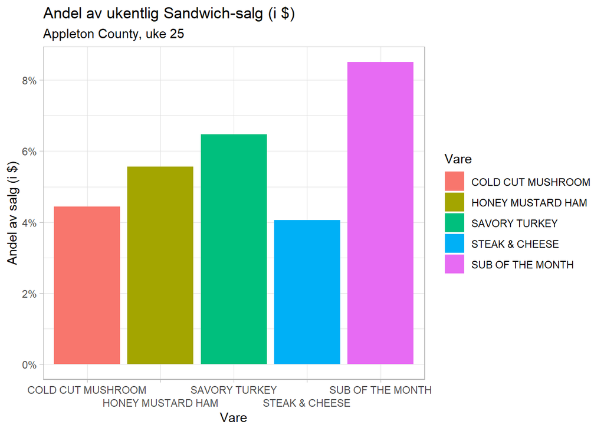

```r
u25.2 %>%
  select(Description, Tot_Sls) %>%
  arrange(-Tot_Sls) %>%
  slice(1:5) %>%
  mutate(D2 = str_remove_all(Description, "REGULAR ")) %>%
  ggplot(aes(x=D2, y=Tot_Sls, fill=D2)) +
  geom_bar(stat = "identity") +
  scale_x_discrete(guide = guide_axis(n.dodge=2)) +
  scale_y_continuous(labels = scales::percent_format(accuracy = 1)) +
  labs(title = "Andel av ukentlig Sandwich-salg (i $)",
       subtitle = "Appleton County, uke 25",
       x = "Vare",
       y = "Andel av salg (i $)") +
  guides(fill=guide_legend(title="Vare")) +
  theme_light()
```

```r
u25.2 %>%
  select(Description, Margin) %>%
  arrange(-Margin) %>%
  head()
```

|  | Description | Margin |
| --- | --- | --- |
| 1 | REGULAR SAVORY TURKEY | 0.0661 |
| 2 | REGULAR SUB OF THE MONTH | 0.0595 |
| 3 | REGULAR HONEY MUSTARD HAM | 0.0497 |
| 4 | REGULAR CHICKEN BACON RANCH | 0.0487 |
| 5 | REGULAR CHICKEN TERIYAKI | 0.0431 |
| 6 | REGULAR STEAK & CHEESE | 0.0414 |

Her kan man se hvilke subs som utgjorde størst andel av butikkens salg denne uken. Månedens sub utgjorde altså 8% av salget. Samtidig kan man se at flere av disse ‘bestselgerne’ også er de sandwichene med høyest profitt-margin. Videre velger jeg å sammenligne med en uke med minst 6 “Bad weather days”.

```r
stats %>%
  select(Week, Weather_Bad_Weather_days, Store_County) %>%
  arrange(Week) %>%
  filter(Store_County == "Appleton County",
         Weather_Bad_Weather_days >= 6) %>%
  distinct(Week, Weather_Bad_Weather_days)
```

| Week | Weather_Bad_Weather_days |
| --- | --- |
| 2 | 7 |
| 3 | 7 |
| 48 | 6 |
| 50 | 6 |
| 51 | 7 |
| 52 | 7 |

Det er 6 uker med veldig dårlig vær. Jeg velger å se nærmere uke 3 (2013), som er en vanlig uke i januar, helt uten høytider o.l. som kan påvirke utsalget.

```r
u3 <- stats %>%
  filter(Store_County == "Appleton County",
         Week == 3) %>%
  filter(str_detect(Description, "REGULAR"))

u3.2 <- u3 %>%
  select(INV_NUMBER, Description, Price, Sold, Sales, Profit, Margin, Tot_Sls,
       Weather_Bad_Weather_Week, Weather_Bad_Weather_days)

u3.2 %>%
  select(Description, Sold, Price, Sales) %>%
  arrange(-Sold) %>%
  head()
```

|  | Description | Sold | Price | Sales |
| --- | --- | --- | --- | --- |
| 1 | REGULAR SUB OF THE MONTH | 103 | 5.00 | 514.00 |
| 2 | REGULAR HONEY MUSTARD HAM | 85 | 5.00 | 425.00 |
| 3 | REGULAR ROASTED CHICKEN | 68 | 6.75 | 459.00 |
| 4 | REGULAR SAVORY TURKEY | 66 | 6.75 | 445.50 |
| 5 | REGULAR CLASSIC TUNA | 55 | 6.75 | 370.58 |
| 6 | REGULAR COLD CUT MUSHROOM | 54 | 5.00 | 270.00 |

I denne uka var det fortsatt ‘månedens sub’ som var den varen det ble solgt flest av i kvantum.

```r
u3.2 %>%
  arrange(-Tot_Sls) %>%
  select(Description, Sold, Price, Sales, Tot_Sls) %>%
  head()
```

|  | Description | Sold | Price | Sales | Tot_Sls |
| --- | --- | --- | --- | --- | --- |
| 1 | REGULAR SUB OF THE MONTH | 103 | 5.00 | 514.00 | 0.0668 |
| 2 | REGULAR ROASTED CHICKEN | 68 | 6.75 | 459.00 | 0.0596 |
| 3 | REGULAR SAVORY TURKEY | 66 | 6.75 | 445.50 | 0.0579 |
| 4 | REGULAR HONEY MUSTARD HAM | 85 | 5.00 | 425.00 | 0.0552 |
| 5 | REGULAR CLASSIC TUNA | 55 | 6.75 | 370.58 | 0.0481 |
| 6 | REGULAR CHICKEN TERIYAKI | 39 | 7.75 | 302.25 | 0.0393 |

```r
u3.2 %>%
  summarise(sum(Sold))
```

| sum(Sold) |
| --- |
| 831 |

```r
u3.2 %>%
  summarise(sum(Profit))
```

| sum(Profit) |
| --- |
| 3449.44 |

Da er det ikke noe sjokk at det var ‘månedens sub’ som utgjorde den største andelen av salget også denne uka. Det ble til sammen solgt 831 sandwicher, noe som endte med en profitt på 3449.44$.

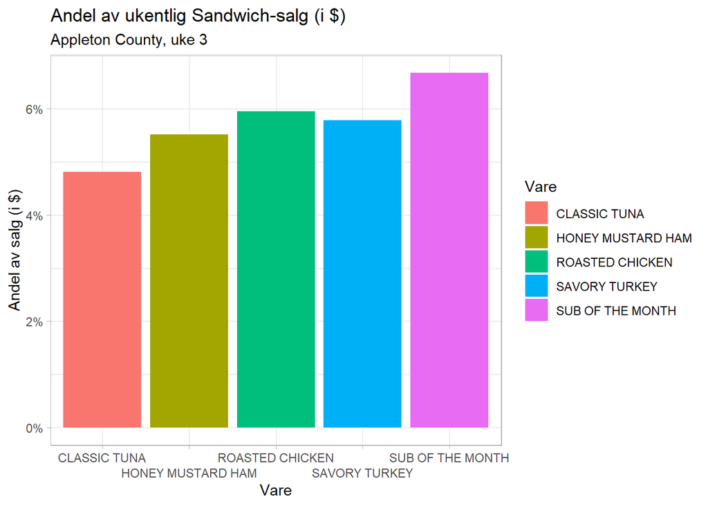

```r
u3.2 %>%
  select(Description, Tot_Sls) %>%
  arrange(-Tot_Sls) %>%
  slice(1:5) %>%
  mutate(D2 = str_remove_all(Description, "REGULAR ")) %>%
  ggplot(aes(x=D2, y=Tot_Sls, fill=D2)) +
  geom_bar(stat = "identity") +
  scale_x_discrete(guide = guide_axis(n.dodge=2)) +
  scale_y_continuous(labels = scales::percent_format(accuracy = 1)) +
  labs(title = "Andel av ukentlig Sandwich-salg (i $)",
       subtitle = "Appleton County, uke 3",
       x = "Vare",
       y = "Andel av salg (i $)") +
  guides(fill=guide_legend(title="Vare")) +
  theme_light()
```

```r
u3.2 %>%
  select(Description, Margin) %>%
  arrange(-Margin) %>%
  head()
```

|  | Description | Margin |
| --- | --- | --- |
| 1 | REGULAR ROASTED CHICKEN | 0.0562 |
| 2 | REGULAR SAVORY TURKEY | 0.0561 |
| 3 | REGULAR CLASSIC TUNA | 0.0513 |
| 4 | REGULAR HONEY MUSTARD HAM | 0.0475 |
| 5 | REGULAR CHICKEN TERIYAKI | 0.0455 |
| 6 | REGULAR SUB OF THE MONTH | 0.0449 |

Det er altså fortsatt månedens sub som gjelder. Det er veldig liten forskjell på hvilke sandwicher det ble solgt flest av, selv om ukene varierer stort - både værmessig og når på året det er. Denne uka var det ‘Roasted Chicken’ som hadde høyest profittmargin. Resten av ‘bestselgerne’ er også blant de med høyest profittmargin, noe som er positivt for bedriften, som selger mest av det de tjener mest per enhet på. Det eneste som har forbedringspotensiale her er å øke profittmarginen på den mestselgende sandwichen, som er ‘månedens sub’. Dette trenger imidlertid ikke nødvendigvis å være nødvendig, ettersom månedens sandwich skifter hver måned, noe som betyr at produksjonskostnad, og derav profittmargin også endres månedlig. Den største forskjellen ligger ved at det kun ble solgt 831 sandwicher denne uka, 376 færre enn i uke 25. Dette ga en profitt på 3449.44 dollar, noe som er 1239 dollar lavere enn profitten på subs fra uke 25. Hvorfor?

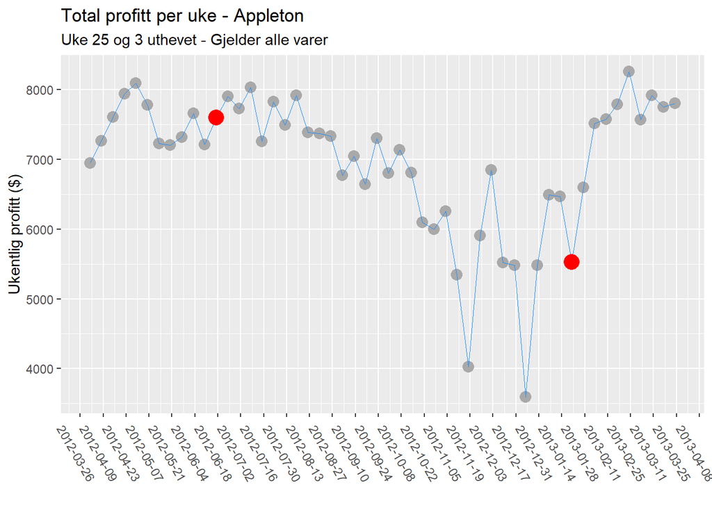

```r
uthev25 <- Oppgave2 %>%
  filter(Week == 25) %>%
  select(Week, Date, Total_Profit_Week, Weather_Bad_Weather_days)

uthev3 <- Oppgave2 %>%
  filter(Week == 3) %>%
  select(Week, Date, Total_Profit_Week, Weather_Bad_Weather_days)

Oppgave2 %>%
  ggplot(aes(x=Date, y=Total_Profit_Week)) +
  geom_point(color = "darkgrey", size = 3.5) +
  geom_line(aes(x=Date, y=Total_Profit_Week),color = "dodgerblue",size = 0.1) +
  geom_point(data=uthev25,
             aes(x = Date, y = Total_Profit_Week),
             color='red',
             size=5) +
  geom_point(data=uthev3,
             aes(x = Date, y = Total_Profit_Week),
             color='red',
             size=5) +
  labs(title = "Total profitt per uke - Appleton",
       subtitle = "Uke 25 og 3 uthevet - Gjelder alle varer",
       x = "",
       y = "Ukentlig profitt ($)") +
  scale_x_date(date_breaks = "2 weeks") +
  theme(axis.text.x = element_text(angle = -60))
```

Dette plotet viser hvordan de to ukene jeg har valgt ligger an i forhold til alle andre uker i datasettet basert på total, ukentlig profitt. Som man kan se ligger uke 25 i det øvre sjiktet av uker med høy profitt, mens uke 3 viser seg å være en av de dårligere ukene. Skulle jeg beskrevet utviklingen i dette plotet, ville jeg påpekt at butikken opprettholder en relativt høy ukentlig profitt helt til sent i oktober, hvor salget dropper drastisk frem til midten av desember - hvor bedriften opplever en voldsom oppgang i ukentlig profitt igjen. Ved årsskiftet faller igjen salget drastisk, og uke 52 er faktisk den uka med lavest profitt i hele datasettet, noe som kanskje skyldes høytid - eller kanskje dårlig vær? Etter dette har ukentlig profitt en jevnlig oppgang, med unntak av uke 3, som er en av to uker jeg har valgt å se nærmere på.

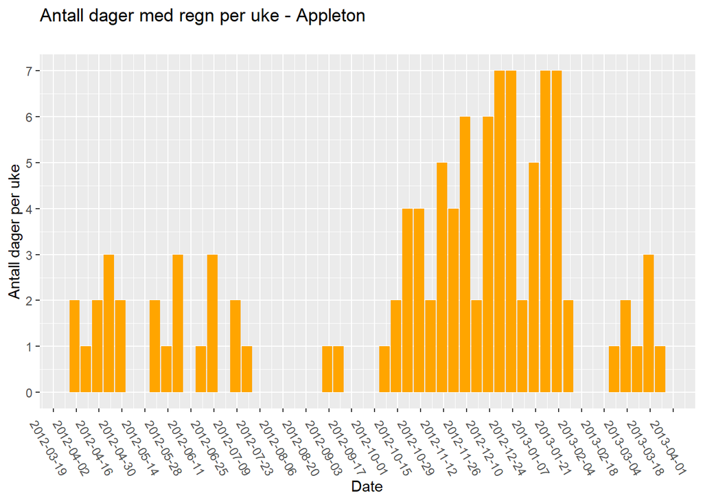

```r
ukentlig <- Oppgave2 %>%
  select(Date, Week, Weather_Bad_Weather_days) %>%
  distinct(Week, .keep_all = TRUE)

ukentlig %>%
  ggplot(aes(x=Date, y=Weather_Bad_Weather_days)) +
  geom_col(aes(y=Weather_Bad_Weather_days),
           alpha = 1,
           fill = "orange") +
  labs(title = "Antall dager med regn per uke - Appleton",
       subtitle = "",
       y = "Antall dager per uke") +
  scale_x_date(date_breaks = "2 weeks") +
  scale_y_continuous(breaks = seq(0, 7, by = 1))+
  theme(axis.text.x = element_text(angle = -60))
```

Her kan man se hvilke uker som hadde flest dager med dårlig vær. Det er relativt få uker med generelt dårlig vær, helt til vi når slutten av oktober hvor antall dager med dårlig vær tar seg opp, frem til tidlig februar.

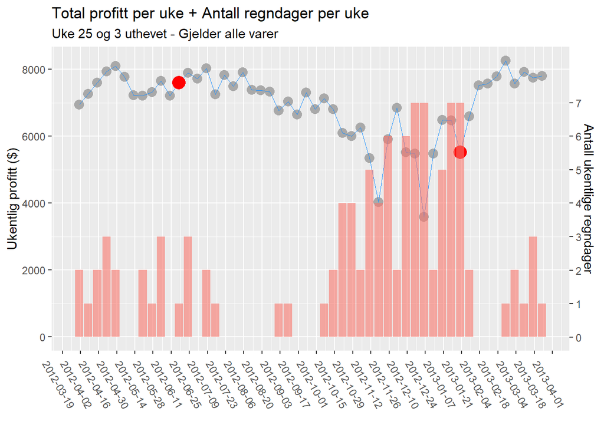

```r
profit_weather <- Oppgave2 %>%
  ggplot(aes(x=Date, y=Total_Profit_Week)) +
  geom_point(color = "darkgrey", size = 3.5) +
  geom_line(aes(x=Date, y=Total_Profit_Week),color = "dodgerblue",size = 0.1) +
  geom_point(data=uthev25,
             aes(x = Date, y = Total_Profit_Week),
             color='red',
             size=5) +
  geom_point(data=uthev3,
             aes(x = Date, y = Total_Profit_Week),
             color='red',
             size=5) +
  geom_col(data = ukentlig,
           aes(y=Weather_Bad_Weather_days*1000, fill = "orange"),
           alpha = 0.6) +
  labs(title = "Total profitt per uke + Antall regndager per uke",
       subtitle = "Uke 25 og 3 uthevet - Gjelder alle varer",
       x = "",
       y = "Ukentlig profitt ($)") +
  scale_x_date(date_breaks = "2 weeks") +
  scale_y_continuous(name = "Ukentlig profitt ($)",
  sec.axis = sec_axis( trans=~./1000, name="Antall ukentlige regndager",
                       breaks = seq(0, 7, by = 1)))+
  theme(axis.text.x = element_text(angle = -60),
        legend.position = "none")
profit_weather
```

Her kan det se ut til at uker med flere dager med dårlig vær påvirker salgstallene negativt. Da profitten begynte å synke mot slutten av oktober, ble det oftere dårlig vær, og da de ukene med dårligst vær hadde passert i tidlig februar, tok også profitten seg opp igjen. Ser man på de aller dårligste ukene til denne avdelingen basert på profitt, skjedde 5 av de 7 ukene med lavest profitt i uker med minst 5 døgn med dårlig vær. For å se om det faktisk er en korrelasjon mellom det dårlige været og profitten velger jeg å kjøre en regresjonsanalyse.

```r
korrelasjon <- Oppgave2 %>%
  select(Week, Weather_Bad_Weather_days, Total_Profit_Week) %>%
  distinct(Week, .keep_all = TRUE)

lm(data = korrelasjon, Weather_Bad_Weather_days ~ Total_Profit_Week)
```

```
##
## Call:
## lm(formula = Weather_Bad_Weather_days ~ Total_Profit_Week, data = korrelasjon)
##
## Coefficients:
##       (Intercept)  Total_Profit_Week
##         12.487458          -0.001499
```

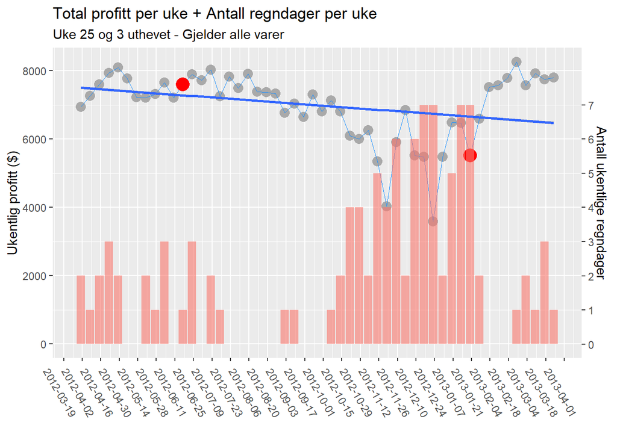

```r
profit_weather + geom_smooth(method = "lm")
```

# Oppgave 3

I denne oppgaven skal jeg velge en måned og se på det totale salget for hele kjeden, altså alle utsalgsstedene i datasettet, for å lage en langsiktig konsernrapport. Her kan man se på hvilke avdelinger som er mest profitable, og hva de gjør rett, samtidig som at man kan se nærmere på hva som kan endres hos avdelingene som ikke er så profitable. Jeg ønsker å se nærmere på de utsalgsstedene som har høyest profitt, samt høyest profitt per innbygger i fylket. At en avdeling har høyere profitt enn en annen, kan begrunnes med at avdelingen er plassert i et område med flere innbyggere, derfor ønsker jeg å se på hva utsalgsstedene tjener på hver innbygger (County_Labor_Force). Kanskje det er forskjell på hvem som tjener mest, og hvem som tjener mest per innbygger? Det er disse avdelingene de andre har noe å lære av, og å se på hva som skiller konsernets avdelinger kan gjøre at de mindre profitable avdelingene blir mer profitable, og dermed øke den totale profitten på lang sikt. Jeg velger å se på en måned jeg ikke har berørt enda. Velger April-måned (2012).

```r
Oppgave3 <- stats %>%
  select(Store_County, Store_Num, Store_Name, Description, Sold, Sales, Price, Profit,
         Unit_Cost, County_Labor_Force, County_Unemployment_Rate, Date, Week, Month, Year,
         Store_Drive_Through) %>%
  group_by(Month) %>%
  mutate(Total_Profit_Month = sum(Profit))

Oppgave3 <- Oppgave3 %>%
  mutate(YM1 = as.numeric(Month-3),
         YM2 = as.numeric((Month+9)))

Oppgave3$YM1 <- replace(Oppgave3$YM1, which(Oppgave3$YM1 < 1), NA)
Oppgave3$YM2 <- replace(Oppgave3$YM2, which(Oppgave3$YM2 < 9), NA)
Oppgave3$YM2 <- replace(Oppgave3$YM2, which(Oppgave3$YM2 > 12), NA)

Oppgave3 <- Oppgave3 %>%
  mutate(Month2 = coalesce(YM1, YM2))
```

Her har jeg satt uke 14 som den første uka i datasettet, for å sørge for at plotet ikke starter med januar 2013, men heller med april 2012.

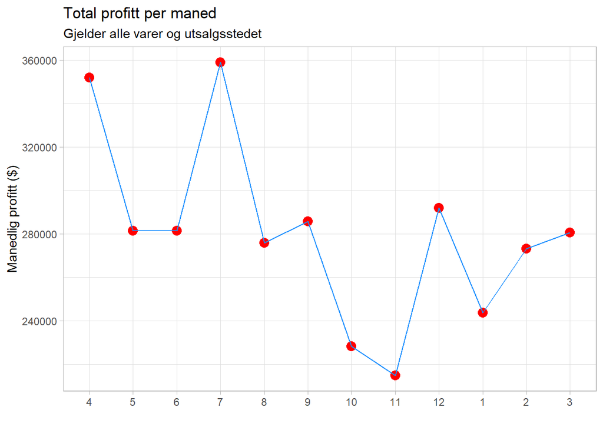

```r
Profitt_per_month <- Oppgave3 %>%
  distinct(Month2, .keep_all = TRUE) %>%
  ggplot(aes(x=Month2, y=Total_Profit_Month)) +
  geom_point(color = "red", size = 3.5) +
  geom_line(aes(x=Month2, y=Total_Profit_Month),color = "dodgerblue",size = 0.5) +
  labs(title = "Total profitt per maned",
       subtitle = "Gjelder alle varer og utsalgsstedet",
       x = "",
       y = "Manedlig profitt ($)") +
  scale_x_discrete(limits = c("4","5","6","7","8","9","10","11","12","1",
                              "2","3")) +
  theme_light()
Profitt_per_month
```

```r
Oppgave3 %>%
  distinct(Month, .keep_all = TRUE) %>%
  select(Month, Total_Profit_Month) %>%
  arrange(-Total_Profit_Month)
```

| Month | Total_Profit_Month |
| --- | --- |
| 7 | 358931.8 |
| 4 | 351997.4 |
| 12 | 291942.4 |
| 9 | 285746.9 |
| 6 | 281497.2 |
| 5 | 281335.6 |
| 3 | 280625.5 |
| 8 | 275951.0 |
| 2 | 273208.8 |
| 1 | 243683.5 |

[output cut: 2 more lines]

April viser seg å være måneden med nest høyest profitt, kun slått av Juli. Måneden med tredje mest profitt er Desember. Det som umiddelbart slår meg er at dette er de tre største ‘ferie-månedene’ amerikanerne har, med sommmerferie i juli, ‘spring-break’ i april (i 2012) og juleferie i desember. Det er flere faktorer som kan spille inn her; Først og fremst kan det bety at man oftere spiser “ute” i ferier. En annen ting kan være at denne bedriften har flest “unge” kunder. April og Juli ligger langt over Desember som er nr. 3 når det kommer til profitt. Kan dette skyldes at det er da elever/studenter er mest ute? Dette er imidlertid noe jeg ikke får sett nærmere på, ettersom jeg ikke har data fra ulike aldersgrupper. Videre vil jeg se på lønnsomheten til de ulike utsalgsstedene.

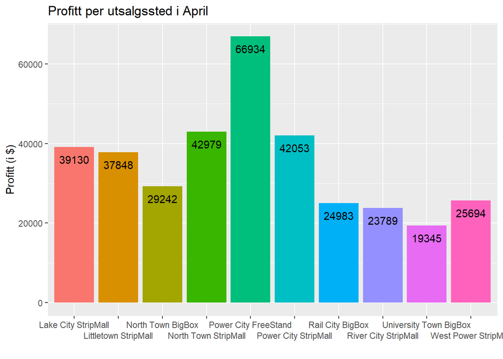

```r
profitt_utsalgssted <- Oppgave3 %>%
  select(Month, Store_Num, Store_Name, Profit) %>%
  filter(Month == 4) %>%
  group_by(Store_Num) %>%
  mutate(Store_Profit_April = sum(Profit)) %>%
  distinct(Store_Num, .keep_all = TRUE) %>%
  ggplot(aes(x=Store_Name, y=Store_Profit_April, fill = Store_Name)) +
  geom_col(aes(y=Store_Profit_April),
           alpha = 1) +
  geom_text(aes(label = round(Store_Profit_April)), vjust=2) +
  labs(title = "Profitt per utsalgssted i April",
       x="",
       y = "Profitt (i $)") +
  scale_x_discrete(guide = guide_axis(n.dodge=2)) +
  theme(legend.position = "none")
profitt_utsalgssted
```

Her kan vi se profitt per utsalgssted i april, hvor Power City Freestand har klart størst profitt. Dette er også den byen i datasettet med nest flest innbyggere, jfr. figuren fra oppgave 2. Dette er definitivt en lønnsom by for bedriften, ettersom Power City Stripmall også er blant topp 3 mest lønnsomme utsalgssteder. Videre kan jeg finne hvert utsalgssted minst profitable vare. Jeg ønsker å finne en ordentlig vare, og fjerner derfor ordene ‘reward’ og ‘free’ fra description, samt 0 fra pris-kolonnen for å få en ordentlig oversikt over de ‘normale’ varene.

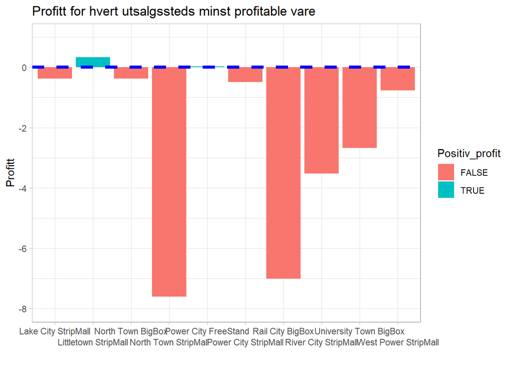

```r
negativ <- Oppgave3 %>%
  filter(Month == 4) %>%
  filter(!str_detect(Description, "REWARD")) %>%
  filter(!str_detect(Description, "FREE")) %>%
  filter(!str_detect(Price, "0")) %>%
  filter(Price > 0) %>%
  group_by(Store_Name) %>%
  arrange(Profit) %>%
  distinct(Store_Name, .keep_all = TRUE) %>%
  select(Store_Name, Store_Num, Description, Sold, Price, Unit_Cost, Profit)

negativ %>%
  mutate(Positiv_profit = Profit >= 0) %>%
  ggplot(aes(x = Store_Name, y = Profit, fill = Positiv_profit)) +
  geom_col(aes(x= Store_Name, y=Profit),
           alpha = 1) +
  geom_hline(yintercept = 0, linetype = "dashed", color = "blue", size = 1.5) +
  scale_x_discrete(guide = guide_axis(n.dodge=2)) +
  scale_y_continuous(limits = c(-8, 1)) +
  labs(title = "Profitt for hvert utsalgssteds minst profitable vare",
       x = "",
       y = "Profitt") +
  theme_light()
```

```r
negativ %>%
  arrange(Profit) %>%
  select(Store_Name, Description, Sold, Price, Unit_Cost, Profit)
```

| Store_Name | Description | Sold | Price | Unit_Cost | Profit |
| --- | --- | --- | --- | --- | --- |
| North Town StripMall | SS CLUB SALAD | 4 | 6.00 | 4.6329 | -7.61 |
| Rail City BigBox | REGULAR TURKEY BACON AVACODO | 3 | 8.75 | 5.3369 | -7.01 |
| River City StripMall | SUNRISE MELT REGULAR FLATBREAD | 2 | 6.25 | 1.7589 | -3.52 |
| University Town BigBox | MINI SUNRISE MELT | -1 | 4.25 | 0.9318 | -2.67 |
| West Power StripMall | MINI SUB OF THE MONTH | 4 | 3.75 | 2.6274 | -0.77 |
| Power City StripMall | MUFFIN SAUS-EGG | 1 | 3.00 | 1.3069 | -0.49 |
| Lake City StripMall | MINI SUB OF THE MONTH | 2 | 3.75 | 2.6274 | -0.38 |
| North Town BigBox | MINI SUB OF THE MONTH | 2 | 3.75 | 2.6274 | -0.38 |
| Power City FreeStand | MINI ROAST BEEF DOUBLE | 1 | 7.50 | 1.9915 | 0.03 |
| Littletown StripMall | MINI TURKEY/HAM/BACON MELT DOUBLE | 1 | 7.25 | 1.6915 | 0.33 |

Her viser figuren at det er North Town Stripmall som har det enkeltutsalget med størst negativ profitt av alle utsalgsstedene. Jeg valgte å lage figuren slik at de utsalgsstedene med positiv profitt fikk en blå “stolpe”, og de med negativ profitt fikk en rød. Det er nesten kun røde stolper, med unntak av 2; Littletown Stripmall og Power City Freestand. Ved å se på tabellen under figuren avslører den at det er SS Club Salad som er den enkeltvaren som går mest med underskudd totalt sett. Det er ikke den mest populære varen, men bedriften tapte altså 7.6$ på å selge denne salaten i North Town Stripmall. Ved å sortere ut slike varer får man en oversikt over hvilke varer det bør gjøres endringer i produksjonen på. Slik kan bedriften forbedre seg ved å gjøre endringer på de varene med lavest profitt på hvert utsalgssted.

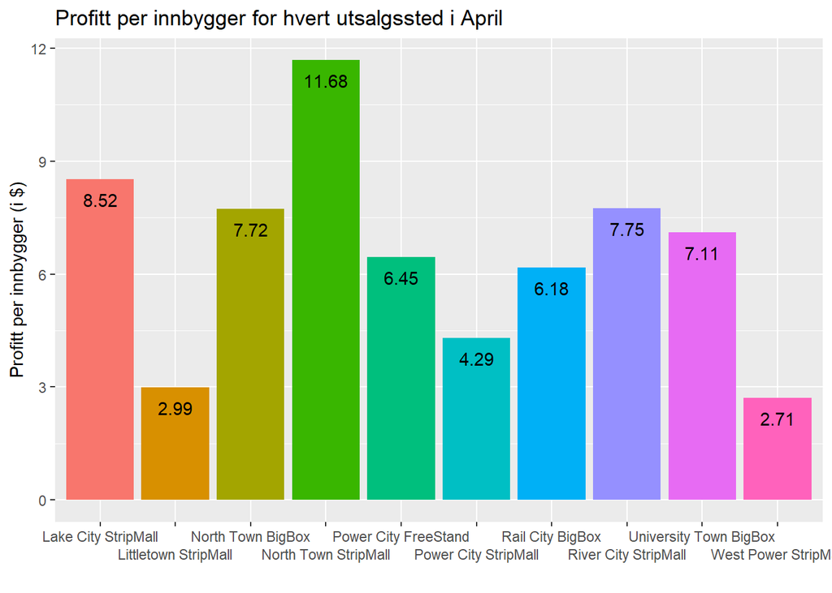

```r
Profitt_per_innbygger <- Oppgave3 %>%
  group_by(Store_Num) %>%
  mutate(Store_Profit = sum(Profit)) %>%
  ungroup() %>%
  mutate(PLB = Store_Profit/County_Labor_Force) %>%
  select(Month, Month2, Store_County, Store_Num, Store_Name, Store_Profit,
         County_Labor_Force, PLB, Store_Drive_Through) %>%
  filter(Month == 4) %>%
  distinct(Store_Name, .keep_all = TRUE)

profitt_utsalgssted_per_innbygger <- Profitt_per_innbygger %>%
  ggplot(aes(x=Store_Name, y=PLB, fill = Store_Name)) +
  geom_col() +
  labs(title = "Profitt per innbygger for hvert utsalgssted i April",
       x="",
       y = "Profitt per innbygger (i $)") +
  scale_x_discrete(guide = guide_axis(n.dodge=2)) +
  geom_text(aes(label = round(PLB, 2), vjust=2)) +
  theme(legend.position = "none")
profitt_utsalgssted_per_innbygger
```

Her har jeg laget en figur for å se hvor mye hvert utsalgssted tjener på hver innbygger i fylket (regner fylkets arbeidsstyrke som innbyggere). På denne måten kan man finne ut hvor befolkningen handler mest hos denne bedriften, og derav kan man kanskje planlegge nye utsalgssteder der hvor avdelingen tjener mest per innbygger? Når det er sagt vil en nyetablering i et område man allerede er etablert i også skape konkurranse for en selv, så det er ikke nødvendigvis alltid lurest å gå for områder man allerede tjener stort på. Sammenligner profitt per innbygger (per utsalgssted) og profitt per utsalgssted

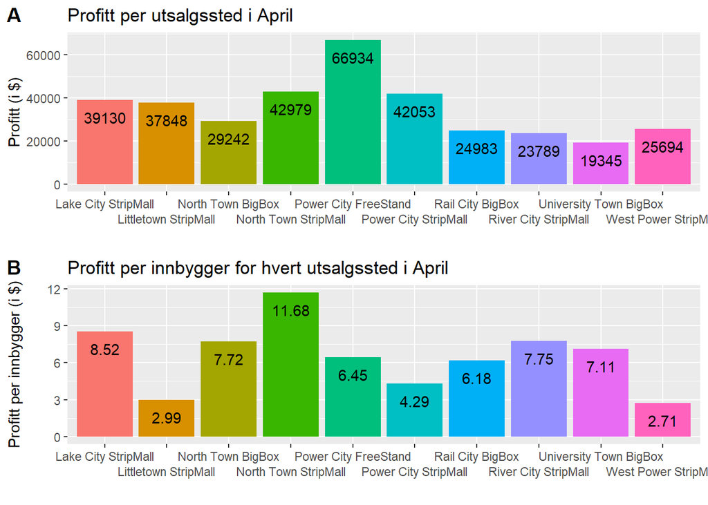

```r
plot_grid(profitt_utsalgssted,
          profitt_utsalgssted_per_innbygger,
          ncol = 1,
          labels = "AUTO",
          align = "v")
```

```r
stats %>%
  select(Store_County, Store_Name, Store_Competition_Fastfood, Store_Competition_Otherfood) %>%
  distinct(Store_Name, .keep_all = TRUE) %>%
  arrange(Store_Competition_Fastfood)
```

| Store_County | Store_Name | Store_Competition_Fastfood | Store_Competition_Otherfood |
| --- | --- | --- | --- |
| Power County | West Power StripMall | 1 | 9 |
| Farm County | North Town StripMall | 2 | 20 |
| River County | University Town BigBox | 2 | 1 |
| Power County | Power City StripMall | 5 | 6 |
| Farm County | North Town BigBox | 6 | 18 |
| Appleton County | Littletown StripMall | 7 | 18 |
| River County | River City StripMall | 8 | 30 |
| Rail County | Rail City BigBox | 8 | 22 |
| Lake County | Lake City StripMall | 8 | 3 |
| Power County | Power City FreeStand | 10 | 25 |

Her kan man se at Power City Freestand (som vi vet har størst profitt av alle i april) ikke tjener så mye per innbygger som andre. Dette skyldes nok at utsalgsstedet er plassert i en stor by med mange innbyggere - og konkurrerende restauranter. Allikevel er det kanskje potensiale for forbedring/utvidelse her - noe som kan gjøre profitten fra denne byen enda større enn den allerede er. Samtidig tjener avdelingen på North Town Stripmall veldig mye per innbygger i forhold til resten av avdelingene; er det noe man kan lære derfra? Ser man på tabellen under figuren kan man se at North Town Stripmall har veldig lav konkurranse fra andre fast food-kjeder.

# Oppgave 4

Å se på hvilke varer bedriften og dens avdelinger opplever lavest profitt av å selge, kan gjøre at bedriften kan se nærmere på hva som fører til den lave profitten. Er det for eksempel høye priser på ‘råvarene’? Om sandwichen koster mye å produsere på grunn av for eksempel dyrt kjøttpålegg kan bedriften se til andre slakterier for å redusere innkjøpsprisen. Videre opplever bedriften høyere salgstall, og derav høyere profitt ved ferier, særlig ‘spring-break’ og sommerferien. Derfor kan konsernledelsen tjene på å investere i ekstra markedsføring og kampanjer i forhånd av disse.

```r
stats %>%
  select(Store_County, Store_Name, Store_Drive_Through, Store_Near_School) %>%
  distinct(Store_Name, .keep_all = TRUE)
```

| Store_County | Store_Name | Store_Drive_Through | Store_Near_School |
| --- | --- | --- | --- |
| Power County | Power City FreeStand | Yes | Yes |
| Power County | West Power StripMall | No | No |
| Power County | Power City StripMall | No | No |
| Appleton County | Littletown StripMall | No | No |
| River County | River City StripMall | No | Yes |
| Rail County | Rail City BigBox | No | No |
| Lake County | Lake City StripMall | Yes | Yes |
| Farm County | North Town StripMall | No | Yes |
| Farm County | North Town BigBox | No | No |
| River County | University Town BigBox | No | No |

```r
Profitt_per_innbygger %>%
  group_by(Store_Drive_Through) %>%
  summarise(mean(PLB))
```

| Store_Drive_Through | mean(PLB) |
| --- | --- |
| No | 6.304801 |
| Yes | 7.486540 |

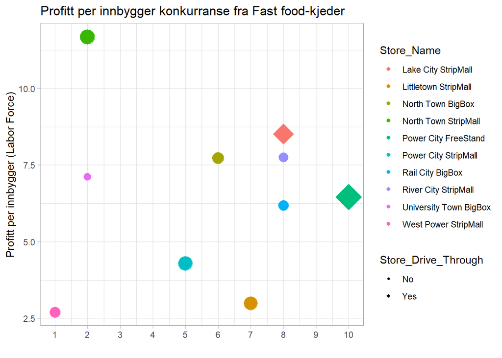

```r
Profitt_vs_competition <- stats %>%
  select(Store_Name, Profit, Store_Competition_Fastfood, Store_Drive_Through,
         County_Labor_Force) %>%
  group_by(Store_Name) %>%
  mutate(Store_Profit = sum(Profit),
         Store_Profit_pr = Store_Profit/County_Labor_Force) %>%
  distinct(Store_Name, .keep_all = TRUE)

Profitt_vs_competition %>%
  ggplot(aes(x=Store_Competition_Fastfood, y=Store_Profit_pr)) +
  geom_point(aes(color=Store_Name, size = Store_Profit,
                 shape = Store_Drive_Through)) +
  scale_size_continuous(range = c(5, 12)) +
  scale_shape_manual(values = c(20, 18)) +
  guides(size = "none") +
  labs(title = "Profitt per innbygger konkurranse fra Fast food-kjeder",
       x="",
       y="Profitt per innbygger (Labor Force)") +
  scale_x_continuous(breaks = seq(1, 10, 1)) +
  theme_light()
```

Derfor vil mine tips til konsernledelsen ved planlegging av nye utsalg være å se etter lokaler i nærheten av travle motorveier i (eller ved utkanten av) større byer, med mulighet for drive-through. I tillegg bør de se etter lokaler i mindre, sentraliserte samfunn (marked) med lav konkurranse - Slik som Farm County.